# Investigate a Dataset Project

## TMDB data set - movies, popularity, budjet, revenues, etc.

```python
import pandas as pd
import numpy as np
import matplotlib.pyplot as plt
import seaborn as sns
%matplotlib inline

pd.set_option('display.max_columns', None)

df=pd.read_csv("tmdb-movies.csv")
df.head()
```

|  | id | imdb_id | popularity | budget | revenue | original_title | cast | homepage | director | tagline | keywords | overview | runtime | genres | production_companies | release_date | vote_count | vote_average | release_year | budget_adj | revenue_adj |
| --- | --- | --- | --- | --- | --- | --- | --- | --- | --- | --- | --- | --- | --- | --- | --- | --- | --- | --- | --- | --- | --- |
| 0 | 135397 | tt0369610 | 32.985763 | 150000000 | 1513528810 | Jurassic World | Chris Pratt\|Bryce Dallas Howard\|Irrfan Khan\|Vi... | http://www.jurassicworld.com/ | Colin Trevorrow | The park is open. | monster\|dna\|tyrannosaurus rex\|velociraptor\|island | Twenty-two years after the events of Jurassic ... | 124 | Action\|Adventure\|Science Fiction\|Thriller | Universal Studios\|Amblin Entertainment\|Legenda... | 6/9/15 | 5562 | 6.5 | 2015 | 1.379999e+08 | 1.392446e+09 |
| 1 | 76341 | tt1392190 | 28.419936 | 150000000 | 378436354 | Mad Max: Fury Road | Tom Hardy\|Charlize Theron\|Hugh Keays-Byrne\|Nic... | http://www.madmaxmovie.com/ | George Miller | What a Lovely Day. | future\|chase\|post-apocalyptic\|dystopia\|australia | An apocalyptic story set in the furthest reach... | 120 | Action\|Adventure\|Science Fiction\|Thriller | Village Roadshow Pictures\|Kennedy Miller Produ... | 5/13/15 | 6185 | 7.1 | 2015 | 1.379999e+08 | 3.481613e+08 |
| 2 | 262500 | tt2908446 | 13.112507 | 110000000 | 295238201 | Insurgent | Shailene Woodley\|Theo James\|Kate Winslet\|Ansel... | http://www.thedivergentseries.movie/#insurgent | Robert Schwentke | One Choice Can Destroy You | based on novel\|revolution\|dystopia\|sequel\|dyst... | Beatrice Prior must confront her inner demons ... | 119 | Adventure\|Science Fiction\|Thriller | Summit Entertainment\|Mandeville Films\|Red Wago... | 3/18/15 | 2480 | 6.3 | 2015 | 1.012000e+08 | 2.716190e+08 |
| 3 | 140607 | tt2488496 | 11.173104 | 200000000 | 2068178225 | Star Wars: The Force Awakens | Harrison Ford\|Mark Hamill\|Carrie Fisher\|Adam D... | http://www.starwars.com/films/star-wars-episod... | J.J. Abrams | Every generation has a story. | android\|spaceship\|jedi\|space opera\|3d | Thirty years after defeating the Galactic Empi... | 136 | Action\|Adventure\|Science Fiction\|Fantasy | Lucasfilm\|Truenorth Productions\|Bad Robot | 12/15/15 | 5292 | 7.5 | 2015 | 1.839999e+08 | 1.902723e+09 |
| 4 | 168259 | tt2820852 | 9.335014 | 190000000 | 1506249360 | Furious 7 | Vin Diesel\|Paul Walker\|Jason Statham\|Michelle ... | http://www.furious7.com/ | James Wan | Vengeance Hits Home | car race\|speed\|revenge\|suspense\|car | Deckard Shaw seeks revenge against Dominic Tor... | 137 | Action\|Crime\|Thriller | Universal Pictures\|Original Film\|Media Rights ... | 4/1/15 | 2947 | 7.3 | 2015 | 1.747999e+08 | 1.385749e+09 |

```python
df.tail(3)
```

|  | id | imdb_id | popularity | budget | revenue | original_title | cast | homepage | director | tagline | keywords | overview | runtime | genres | production_companies | release_date | vote_count | vote_average | release_year | budget_adj | revenue_adj |
| --- | --- | --- | --- | --- | --- | --- | --- | --- | --- | --- | --- | --- | --- | --- | --- | --- | --- | --- | --- | --- | --- |
| 10863 | 39768 | tt0060161 | 0.065141 | 0 | 0 | Beregis Avtomobilya | Innokentiy Smoktunovskiy\|Oleg Efremov\|Georgi Z... | NaN | Eldar Ryazanov | NaN | car\|trolley\|stealing car | An insurance agent who moonlights as a carthie... | 94 | Mystery\|Comedy | Mosfilm | 1/1/66 | 11 | 6.5 | 1966 | 0.000000 | 0.0 |
| 10864 | 21449 | tt0061177 | 0.064317 | 0 | 0 | What's Up, Tiger Lily? | Tatsuya Mihashi\|Akiko Wakabayashi\|Mie Hama\|Joh... | NaN | Woody Allen | WOODY ALLEN STRIKES BACK! | spoof | In comic Woody Allen's film debut, he took the... | 80 | Action\|Comedy | Benedict Pictures Corp. | 11/2/66 | 22 | 5.4 | 1966 | 0.000000 | 0.0 |
| 10865 | 22293 | tt0060666 | 0.035919 | 19000 | 0 | Manos: The Hands of Fate | Harold P. Warren\|Tom Neyman\|John Reynolds\|Dian... | NaN | Harold P. Warren | It's Shocking! It's Beyond Your Imagination! | fire\|gun\|drive\|sacrifice\|flashlight | A family gets lost on the road and stumbles up... | 74 | Horror | Norm-Iris | 11/15/66 | 15 | 1.5 | 1966 | 127642.279154 | 0.0 |

#### Problem we should take care (later):

we see here a problem in the tail!  
in some movies the budjet, revenue, budjet_adj, and revenue_adj have wrotten as 0 !  
we need to remember this when we making calculations based on the budjet/ revenue.

```python
df.shape
```

```
(10866, 21)
```

```python
df.columns
```

```
Index(['id', 'imdb_id', 'popularity', 'budget', 'revenue', 'original_title',
       'cast', 'homepage', 'director', 'tagline', 'keywords', 'overview',
       'runtime', 'genres', 'production_companies', 'release_date',
       'vote_count', 'vote_average', 'release_year', 'budget_adj',
       'revenue_adj'],
      dtype='object')
```

```python
df.dtypes
```

```
id                        int64
imdb_id                  object
popularity              float64
budget                    int64
revenue                   int64
original_title           object
cast                     object
homepage                 object
director                 object
tagline                  object
keywords                 object
overview                 object
runtime                   int64
genres                   object
production_companies     object
release_date             object
vote_count                int64
vote_average            float64
release_year              int64
budget_adj              float64
revenue_adj             float64
dtype: object
```

## Questions:

Is the profit of movies changes over the years ?  
who are the directors their movies get highest votes ?  
is there a corrlation between budget and popularity ?  
Top directors who directs the bigest number of movies?  
what is the optimal run-time for movie ?  
is there a correlation between popularity and vote_average ?

### Cheange types:

```python
# change to datetime:

df['release_date'] = pd.to_datetime(df['release_date'])
```

```python
df.dtypes
```

```
id                               int64
imdb_id                         object
popularity                     float64
budget                           int64
revenue                          int64
original_title                  object
cast                            object
homepage                        object
director                        object
tagline                         object
keywords                        object
overview                        object
runtime                          int64
genres                          object
production_companies            object
release_date            datetime64[ns]
vote_count                       int64
vote_average                   float64
release_year                     int64
budget_adj                     float64
revenue_adj                    float64
dtype: object
```

### Drop columns we dont use:

```python
# drop columns we dont need :
df = df.drop(columns=['imdb_id', 'budget','revenue','homepage','cast'
                      ,'tagline','overview','production_companies','vote_count',"keywords"])
```

```python
df.head(2)
```

|  | id | popularity | original_title | director | runtime | genres | release_date | vote_average | release_year | budget_adj | revenue_adj |
| --- | --- | --- | --- | --- | --- | --- | --- | --- | --- | --- | --- |
| 0 | 135397 | 32.985763 | Jurassic World | Colin Trevorrow | 124 | Action\|Adventure\|Science Fiction\|Thriller | 2015-06-09 | 6.5 | 2015 | 1.379999e+08 | 1.392446e+09 |
| 1 | 76341 | 28.419936 | Mad Max: Fury Road | George Miller | 120 | Action\|Adventure\|Science Fiction\|Thriller | 2015-05-13 | 7.1 | 2015 | 1.379999e+08 | 3.481613e+08 |

### Check if there are nulls in the remains columns:

```python
df.isna().sum()
```

```
id                 0
popularity         0
original_title     0
director          44
runtime            0
genres            23
release_date       0
vote_average       0
release_year       0
budget_adj         0
revenue_adj        0
dtype: int64
```

```python
# because we have big db with above 10,000 rows , i will drop all the rows with null values.
# after removing columns, there are rows like this only in "genres" and "director":
df.dropna(inplace=True)
df.shape
```

```
(10801, 11)
```

#### Create "profit" Column:

```python
# add column profit:
df["profit_adj"] = df["revenue_adj"]-df["budget_adj"]
```

```python
df.head()
```

|  | id | popularity | original_title | director | runtime | genres | release_date | vote_average | release_year | budget_adj | revenue_adj | profit_adj |
| --- | --- | --- | --- | --- | --- | --- | --- | --- | --- | --- | --- | --- |
| 0 | 135397 | 32.985763 | Jurassic World | Colin Trevorrow | 124 | Action\|Adventure\|Science Fiction\|Thriller | 2015-06-09 | 6.5 | 2015 | 1.379999e+08 | 1.392446e+09 | 1.254446e+09 |
| 1 | 76341 | 28.419936 | Mad Max: Fury Road | George Miller | 120 | Action\|Adventure\|Science Fiction\|Thriller | 2015-05-13 | 7.1 | 2015 | 1.379999e+08 | 3.481613e+08 | 2.101614e+08 |
| 2 | 262500 | 13.112507 | Insurgent | Robert Schwentke | 119 | Adventure\|Science Fiction\|Thriller | 2015-03-18 | 6.3 | 2015 | 1.012000e+08 | 2.716190e+08 | 1.704191e+08 |
| 3 | 140607 | 11.173104 | Star Wars: The Force Awakens | J.J. Abrams | 136 | Action\|Adventure\|Science Fiction\|Fantasy | 2015-12-15 | 7.5 | 2015 | 1.839999e+08 | 1.902723e+09 | 1.718723e+09 |
| 4 | 168259 | 9.335014 | Furious 7 | James Wan | 137 | Action\|Crime\|Thriller | 2015-04-01 | 7.3 | 2015 | 1.747999e+08 | 1.385749e+09 | 1.210949e+09 |

#### Check 0 values in the budjet and revenues columns:

```python
# there are a lot of movies with 0 values in the columns budget_adj , revenue_adj.
# they could destroy our statistics , so lets see how much they are:
df[df["budget_adj"]==0].count()
# there are 5636
df[df["revenue_adj"]==0].count()
# there are 5952
# so when we deal with budjet or revenues , we will remove all that lines.
# when we deal with other properties, we will stay all like it is.
```

```
id                5952
popularity        5952
original_title    5952
director          5952
runtime           5952
genres            5952
release_date      5952
vote_average      5952
release_year      5952
budget_adj        5952
revenue_adj       5952
profit_adj        5952
dtype: int64
```

### who are the directors their movies get highest votes ?

```python
df_directors_votes = df.groupby('director').mean()['vote_average'].sort_values(ascending=False)[:10]
df_directors_votes
```

```
director
Mark Cousins                                   9.20
Derek Frankowski                               8.80
David Mallet                                   8.70
Curt Morgan                                    8.50
Saul Swimmer                                   8.50
Martin Scorsese|Michael Henry Wilson           8.50
Jorge RamÃrez SuÃ¡rez                         8.40
D.A. Pennebaker|David Dawkins|Chris Hegedus    8.40
Anthony Mandler                                8.40
Sam Dunn|Scot McFadyen                         8.35
Name: vote_average, dtype: float64
```

```python
# a function to create bar plot with parameters:
def create_plot(x,y,
                plot_color,
                xlab, ylab,
                lab_size,
                title,
                title_size,
                lab_and_title_color,
                xtick_rotation,
                tick_size,tick_color,fig_size_x=15,fig_size_y=10,plt_kind='bar'):
    fig = plt.figure(figsize = (fig_size_x, fig_size_y))
      # creating the bar plot
    if plt_kind=='bar':
        plt.bar(x,y, color =plot_color);
    plt.xlabel(xlab,fontsize = lab_size,color = lab_and_title_color)
    plt.ylabel(ylab,fontsize = lab_size,color = lab_and_title_color)
    plt.title(title,fontsize=title_size,color = lab_and_title_color)
    plt.xticks(rotation = xtick_rotation)
    plt.tick_params(labelsize=tick_size,labelcolor=tick_color)
```

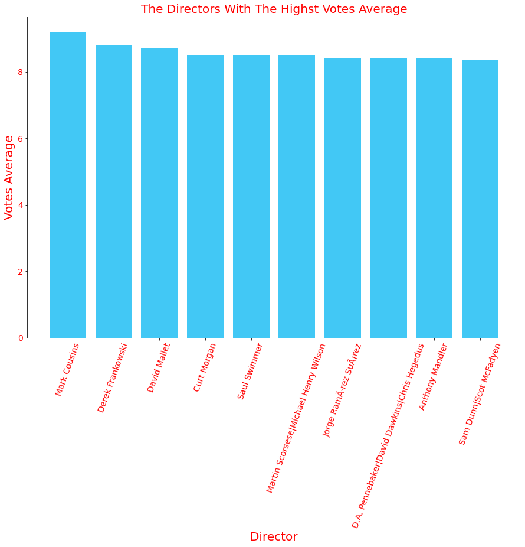

```python
create_plot(x=df_directors_votes.index,y=df_directors_votes.values,
                plot_color='#42c8f5',
                xlab ="Director", ylab = "Votes Average",
                lab_size=20,
                title="The Directors With The Highst Votes Average",
                title_size =20,
                lab_and_title_color='red',
                xtick_rotation =70,
                tick_size=14,
                tick_color='red')
```

### Top directors who directs the bigest number of movies?

```python
df_directors_number = df["director"].value_counts()[0:10]
```

```python
df_directors_number
```

```
Woody Allen          45
Clint Eastwood       34
Steven Spielberg     29
Martin Scorsese      29
Ridley Scott         23
Steven Soderbergh    22
Ron Howard           22
Joel Schumacher      21
Brian De Palma       20
Wes Craven           19
Name: director, dtype: int64
```

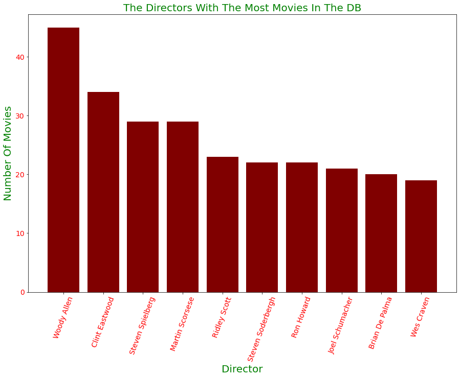

```python
create_plot(x= df_directors_number.index,
                y=df_directors_number.values,
                plot_color='maroon',
                xlab ="Director", ylab = "Number Of Movies",
                lab_size=20,
                title="The Directors With The Most Movies In The DB",
                title_size =20,
                lab_and_title_color='green',
                xtick_rotation =70,
                tick_size=14,
                tick_color='red')
```

### what is the optimal run-time for movie?

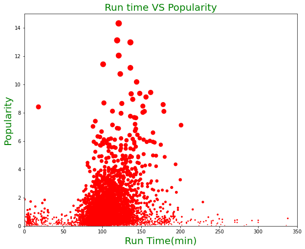

```python
plt.figure(figsize=(10, 8))

x = df['runtime']
y = df['popularity']
area = df['popularity']  *10
plt.xlim([0, 350])
plt.ylim([0, 15])
plt.xlabel("Run Time(min)",fontsize=20,color="green")
plt.ylabel("Popularity",fontsize=20,color="green")
plt.title("Run time VS Popularity",fontsize=20,color="green")
plt.scatter(x, y, s=area,color='red');
```

#### answer: seems that it's between 80 to 150 min.

### is there a correlation between popularity and vote_average ?

### is there a corrlation between budget and popularity ?

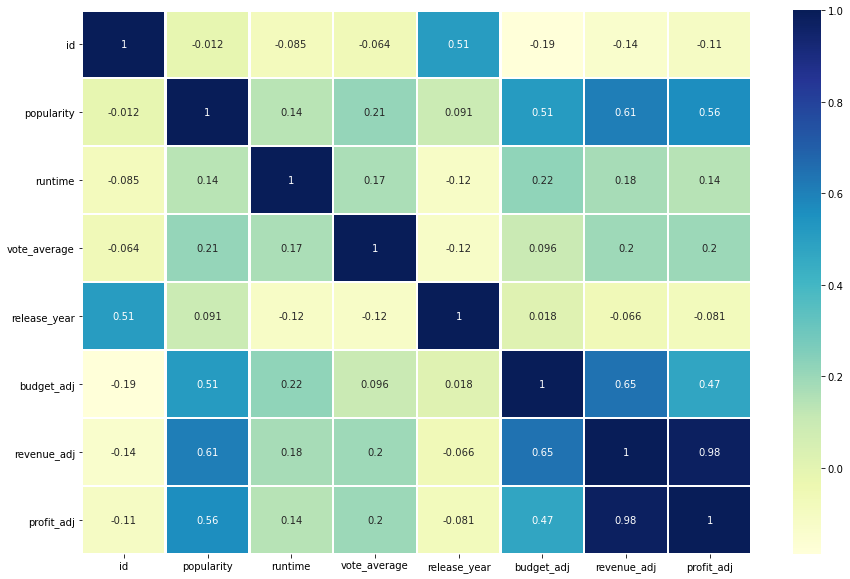

```python
numerical= df.select_dtypes([np.number])
plt.figure(figsize=(15, 10))
sns.heatmap(numerical.corr(), linewidth=1.5,annot=True,cmap="YlGnBu")
```

#### we could see here a heatmap which measures the correlations between features.

#### we see a weak correlation between votes and popularity ! 0.213

#### we see a good correlation between budjet and popularity ! 0.51

#### we see even better correlation between revenue and popularity ! 0.6

#### we see a good correlation between budjet and revenue too ! 0.64

### I think that we need to explore two things to answer on this question:

1. on the aspect of single movie - is there is more profit or less for single movie.
2. on the overall aspect - is there are today more movies per year than in the past ?

### before we answer questions about profit, budget and revenue, we will remove all the columns with 0 in this columns.

```python
df.head()
```

|  | id | popularity | original_title | director | runtime | genres | release_date | vote_average | release_year | budget_adj | revenue_adj | profit_adj |
| --- | --- | --- | --- | --- | --- | --- | --- | --- | --- | --- | --- | --- |
| 0 | 135397 | 32.985763 | Jurassic World | Colin Trevorrow | 124 | Action\|Adventure\|Science Fiction\|Thriller | 2015-06-09 | 6.5 | 2015 | 1.379999e+08 | 1.392446e+09 | 1.254446e+09 |
| 1 | 76341 | 28.419936 | Mad Max: Fury Road | George Miller | 120 | Action\|Adventure\|Science Fiction\|Thriller | 2015-05-13 | 7.1 | 2015 | 1.379999e+08 | 3.481613e+08 | 2.101614e+08 |
| 2 | 262500 | 13.112507 | Insurgent | Robert Schwentke | 119 | Adventure\|Science Fiction\|Thriller | 2015-03-18 | 6.3 | 2015 | 1.012000e+08 | 2.716190e+08 | 1.704191e+08 |
| 3 | 140607 | 11.173104 | Star Wars: The Force Awakens | J.J. Abrams | 136 | Action\|Adventure\|Science Fiction\|Fantasy | 2015-12-15 | 7.5 | 2015 | 1.839999e+08 | 1.902723e+09 | 1.718723e+09 |
| 4 | 168259 | 9.335014 | Furious 7 | James Wan | 137 | Action\|Crime\|Thriller | 2015-04-01 | 7.3 | 2015 | 1.747999e+08 | 1.385749e+09 | 1.210949e+09 |

```python
df_without_zero= df[(df["revenue_adj"]!=0) & (df["budget_adj"]!=0)]
df_without_zero.shape
```

```
(3854, 12)
```

```python
df_years= df_without_zero.groupby("release_year").mean()['profit_adj']
```

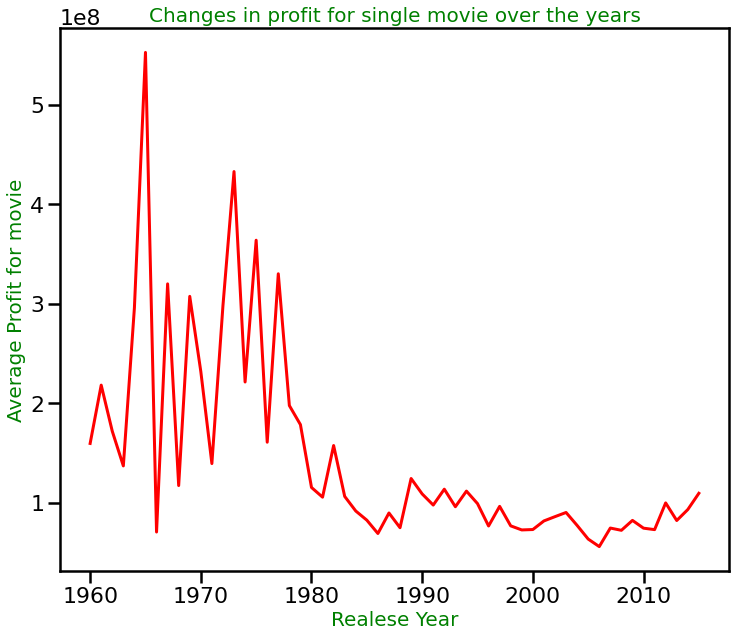

```python
plt.figure(figsize=(12, 10))
plt.xlabel("Realese Year",fontsize=20,color="green")
plt.ylabel("Average Profit for movie",fontsize=20,color="green")
plt.title("Changes in profit for single movie over the years",fontsize=20,color="green")
sns.set_context("poster")
sns.lineplot(data=df_years,color='red');
```

###### we see that the average profit per movies declines over the years !

#### the mean profit for single movie, is less today than in the past !

#### now we go to the second aspect - movies per year:

```python
movies_per_year = df["release_year"].value_counts()
```

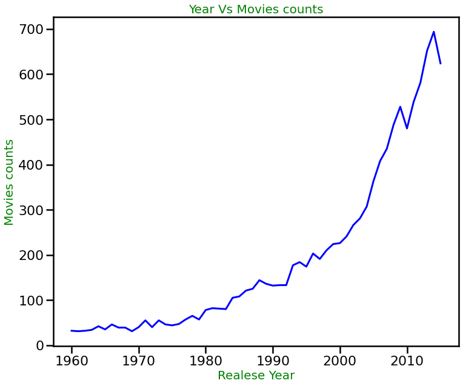

```python
plt.figure(figsize=(12, 10))
plt.xlabel("Realese Year",fontsize=20,color="green")
plt.ylabel("Movies counts",fontsize=20,color="green")
plt.title("Year Vs Movies counts",fontsize=20,color="green")
sns.set_context("poster")
sns.lineplot(data=movies_per_year,color='blue');
```

#### we see very clearly that there are more movies per year over the years

#### on one hand there are more movies per year, on the other hand every single movie is less profitable.

#### so let's check the sum of profit to every year !

```python
### we will use the df_without_zero - df we reduced the rows with 0 values
### from the budjet and profit.
df_sum_profits = df_without_zero.groupby("release_year").sum()["profit_adj"]
# df_sum_profits
```

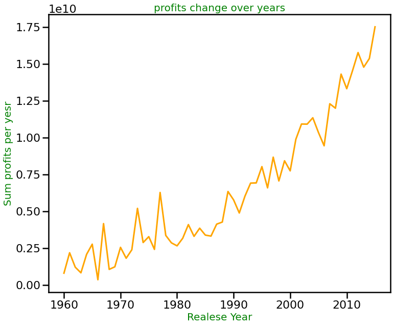

```python
plt.figure(figsize=(12, 10))
plt.xlabel("Realese Year",fontsize=20,color="green")
plt.ylabel("Sum profits per yesr",fontsize=20,color="green")
plt.title("profits change over years",fontsize=20,color="green")
sns.set_context("poster")
sns.lineplot(data=df_sum_profits,color='orange');
```

## conclusion:

### even the profit for a single value decline over the years, the sum of the profit has rose, because there are much more movies every year !!!

## limitations:

#### We haven't information about the methods of gathering the data. for exemple: what's the meanning of "popularity" ? who voted ? what are the adjasment methods of the revenues and budjet ? , what movies are in the DB and what not ? etc. So all that analysis process based on the assumption that the gathering of the data is correct.

#### there are many 0 values in the budjet and revenues columns. when we did calculations which involve budjet/revenue. That is a clear error, because it isn't possible that so many movies didn't had any bujet or revenue. So we have removed that rows (above 5000 rows) and stay with over 3800 rows. it could be that our calculations are not correct, because we removed a lot of movies.